# Olist Seller Analysis

## Background

Olist is a Brazillian e-commerce company that helps small businesses sell goods to customers. 📭  
The customers can then leave reviews for their orders from the sellers. ⭐️  
Due to poor reviews (and some other factors), some sellers end up costing Olist quite a bit of money. 👎  
How can olist minimize these costs❓

*️⃣ This analysis used the [public Olist dataset](https://www.kaggle.com/datasets/olistbr/brazilian-ecommerce), which contains data for 100k+ orders from 2016-2018

## Olist should remove the worst performing sellers from its platform 😲

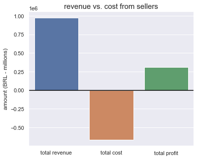

Notice the huge cost! Our goal is to:

- find which sellers are contributing the most to the cost
- identify criteria for removing sellers

## Which sellers should be removed? 🤔

use just one criteria:

- Total accumulated loss for Olist from that seller is -450 BRL or more 💰

### Analyzing Sellers whose Cost > Revenue

**Revenue** 😎  
Olist gets 💲 from sellers due to receiving:

- 10% of sale price per order
- 80 BRL per month subscription fee

**Cost** 😢  
Olist loses 💲 from sellers due to:

- Bad customer reviews 👎
- IT costs 🖥

*NOTE* For this analysis, we make two assumptions:

- each poor review costs Olist the following:

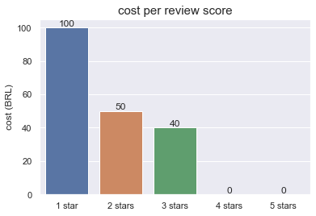

- IT costs are proportional to the square root of the number of orders:

$ total\;IT\;costs = \sqrt{total\;number\;of\;orders} = 500,000\;BRL $

With these assumptions, we can calculate the profitability of each seller, and sort them from most profitable to least profitable

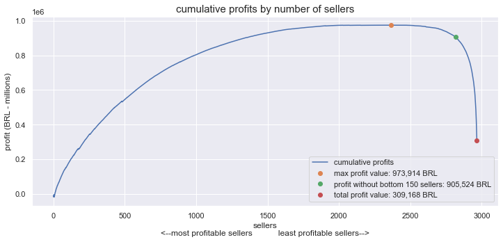

- All the sellers to the right of the orange dot are unprofitable sellers for Olist
- The bottom 150 sellers (5% of all sellers) account for about 90% of lost profits 🤯
- The profit cutoff for the bottom 150 sellers is about -450 BRL 📉

Here's a look at the profit outliers

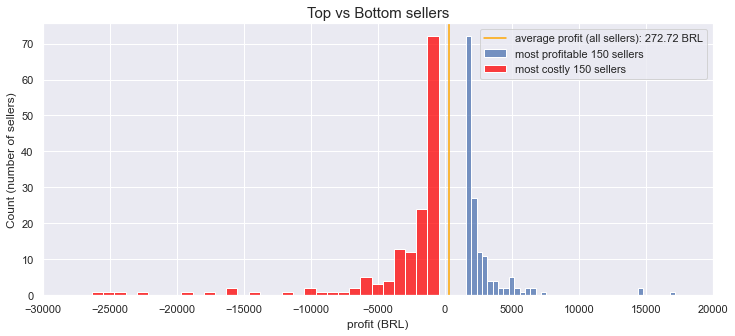

#### Shouldn't we cut ALL sellers with a net loss (i.e. whose costs for Olist exceed their revenue)? 🤔

🙅‍♂️ No! We don't want to punish new sellers or low-order sellers, as this could negatively impact Olist's reputation and future sellers

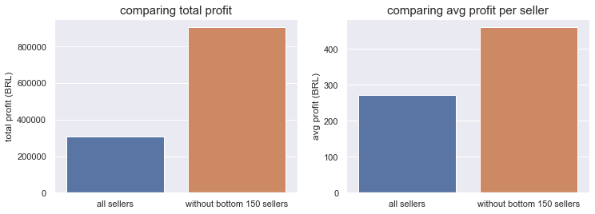

**without the bottom 150 sellers, Olist could have saved nearly 600,000 BRL in costs associated with review scores and IT** 😲

By removing any seller whose net loss reaches -450 BRL, Olist can minimize the affect of those costs

By setting the limit at -450 BRL (and not 0 BRL), Olist can avoid unfairly removing the following sellers who may have a small net loss:

- new sellers
- low-order sellers
- well-established sellers with an insignificant net loss

## Analyzing the bottom sellers

The bottom 150 sellers have more one-star reviews and fewer five-star reviews than other sellers

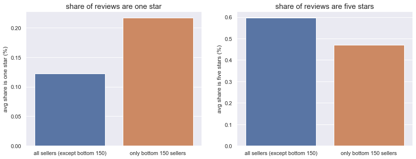

- Almost 22% of all reviews for the bottom 150 sellers are one star reviews - nearly 10% more than other sellers
- Almost 60% of all reviews for most sellers are five star reviews. For the bottom 150 sellers, it's about 47%

By creating logistic regression models for orders that received reviews of one star and five stars, we can see which features were most important for determining the score 🤓

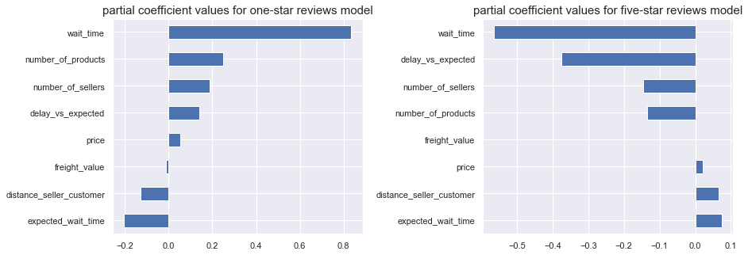

- For one star reviews, the total wait time for delivery was much more influential than the other features at indicating a one-star review
- For five star reviews, delay of the expected wait time was quite influential in preventing a five-star review (in addition to the total wait time)

### So basically ...

The shorter the wait time for delivery, the less likely the order will receive a one-star review, thus preventing costs associated with poor reviews

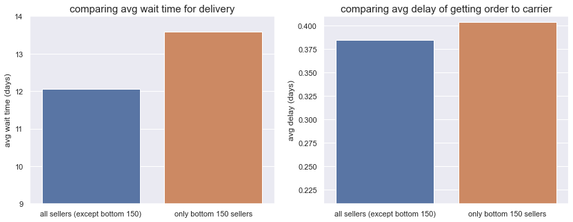

- the average wait time for delivery from the bottom 150 sellers is 1.5 days slower than the rest of the sellers ⏱
- the average delay of getting the order to the carrier is 0.02 days (about half an hour) slower for the bottom 150 sellers 📦

## Recommendations

- Olist should remove sellers with a net loss of -450 BRL or more 📉
- Risky sellers should be identified as soon as possible using the following criteria:
  - their cost for Olist outweighs their revenue 💵
  - share of one star reviews is 20% or more ⭐️
  - average wait time for delivery is 13.5 days or more ⏳
- Once a risky seller is identified, they can receive support from Olist to help increase their share of 5 star reviews and decrease the wait time for delivery 🤗